# Getting Started with semanticfa

## Overview

`semanticfa` performs exploratory factor analysis on language model embeddings of psychological scale items. Given item text, it embeds each item, computes a similarity matrix, and extracts latent factors — entirely from the text, with no human response data required.

The package is designed to feel familiar to `psych` and `EFAtools` users.

## Quick start with bundled data

The package ships with the 50-item IPIP Big Five inventory and precomputed Qwen3-Embedding-8B embeddings (50 x 4096, rounded to 4 decimal places), so you can try it with zero setup:

```r
library(semanticfa)
data(big5)

fit <- sfa(
  big5$items,
  nfactors    = 5,
  embeddings  = big5$embeddings,
  scoring     = big5$scoring
)
print(fit)
```

```
#> Semantic Factor Analysis
#>   Encoding: atomic
#>   Embedding dim: 4096
#>   Factors:5 (minres + oblimin)
#>
#> Diagnostics:
#>   KMO:  0.971 (marvelous - higher is better)
#>   TEFI: -27.7158 (lower is better)
#>   RMSR: 0.0323 (good - lower is better)
#>   CAF:  0.4120 (marginal - higher is better)
#>
#> Factor loadings:
#>
#> Loadings:
#>         MR2    MR3    MR5    MR1    MR4
#> item_16  1.003
#> item_19  0.870
#> item_18  0.861
#> item_11  0.817
#> item_15  0.801
#> item_17  0.790
#> item_20  0.575
#> item_29  0.553                0.390
#> item_13  0.490
#> item_24  0.453                0.425
#> item_26  0.391                0.303
#> item_23
#> item_35         0.715
#> item_39         0.675
#> item_31         0.626
#> item_32         0.617
#> item_40         0.604
#> item_37         0.567
#> item_38         0.566  0.337
#> item_36         0.566
#> item_33         0.565
#> item_04         0.545
#> item_34  0.355  0.502
#> item_28         0.458         0.308
#> item_12         0.395         0.347
```

[output cut: 31 more lines]

```
#> Factor correlations (Phi):
#>       MR2   MR3   MR5   MR1   MR4
#> MR2 1.000 0.684 0.607 0.576 0.540
#> MR3 0.684 1.000 0.538 0.581 0.555
#> MR5 0.607 0.538 1.000 0.465 0.447
#> MR1 0.576 0.581 0.465 1.000 0.398
#> MR4 0.540 0.555 0.447 0.398 1.000
#>
#> Variance accounted for:
#>                         MR2   MR3   MR5   MR1   MR4
#> SS loadings           9.240 8.619 6.284 5.612 4.842
#> Proportion Var        0.185 0.172 0.126 0.112 0.097
#> Cumulative Var        0.185 0.357 0.483 0.595 0.692
#> Proportion Explained  0.267 0.249 0.182 0.162 0.140
#> Cumulative Proportion 0.267 0.516 0.698 0.860 1.000
```

## Factor retention

When you omit `nfactors`, `sfa()` uses embedding-adapted parallel analysis (random unit vectors in the embedding dimension as the null):

```r
fit_auto <- sfa(
  big5$items,
  embeddings = big5$embeddings,
  scoring    = big5$scoring
)
cat("Auto-detected factors:", fit_auto$factors, "\n")
```

```
#> Auto-detected factors: 5
```

For a multi-method comparison, use `sfa_nfactors()`:

```r
sim <- sfa_similarity(big5$embeddings, encoding = "atomic_reversed",
                      scoring = big5$scoring)
nf <- sfa_nfactors(sim, big5$embeddings,
                   methods = c("parallel", "kaiser"),
                   parallel_iter = 50)
print(nf)
```

```
#> Factor retention analysis (embedding-adapted)
#>
#>   Method       n_factors
#>   parallel     5
#>   kaiser       6
#>   ------------------------
#>   Consensus    5
#>
#> Eigenvalues: 29.62   1.92   1.74   1.48   1.27   1.01   0.93   0.88   0.78   0.70  ...
```

## Encoding methods

The `encoding` argument controls how embeddings become a similarity matrix:

```r
sim_ar  <- sfa_similarity(big5$embeddings, "atomic_reversed", big5$scoring)
sim_sq  <- sfa_similarity(big5$embeddings, "squid", big5$scoring)
sim_mcp <- sfa_similarity(big5$embeddings, "mean_centered_pearson", big5$scoring)
cat("atomic_reversed range:", range(sim_ar[lower.tri(sim_ar)]), "\n")
```

```
#> atomic_reversed range: -0.7766852 0.9381671
```

```r
cat("squid range:          ", range(sim_sq[lower.tri(sim_sq)]), "\n")
```

```
#> squid range:           -0.2671767 0.8269712
```

```r
cat("mean_centered_pearson:", range(sim_mcp[lower.tri(sim_mcp)]), "\n")
```

```
#> mean_centered_pearson: 0.3938766 0.9382228
```

The ranges show what each encoding does to the sign structure. Sign-flipping (`atomic_reversed`) manufactures strong negatives by turning reverse-keyed items into anti-topic vectors, and SQuID’s questionnaire-mean centering recovers a modest negative range. Mean-centered Pearson tracks the raw cosines, which stay positive for these items.

## Visualization

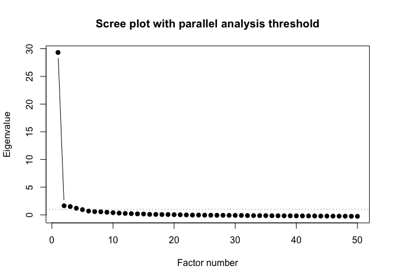

Scree plot with parallel analysis threshold

```r
plot(fit, type = "scree")
```

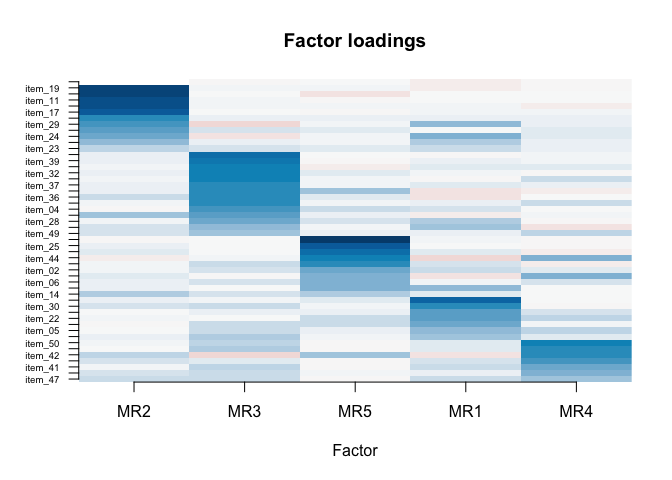

Factor loading heatmap

```r
plot(fit, type = "loadings")
```

## Comparing with empirical factor analysis

The `$loadings` component works directly with `psych` functions:

```r
# Run human-data EFA (not run — requires response data)
human_fit <- psych::fa(response_data, nfactors = 5, rotate = "oblimin")

# Compare
psych::factor.congruence(fit$loadings, human_fit$loadings)
```

For NMI, ARI, Frobenius, and disattenuated correlation:

```r
cong <- sfa_congruence(fit, big5$factors, metrics = c("nmi", "ari"))
print(cong)
```

```
#> Factor structure congruence
#>
#>   NMI:            0.527 (moderate - higher is better)
#>   ARI:            0.402 (weak - higher is better)
```

## Using your own embeddings

Pass any embedding model’s output via `embeddings=`:

```r
# With sentence-transformers (requires reticulate + Python).
# The default model is "Qwen/Qwen3-Embedding-0.6B"; larger models such as
# "Qwen/Qwen3-Embedding-4B" (8 GB RAM) or "Qwen/Qwen3-Embedding-8B" (16 GB RAM)
# recover factor structure more accurately.
emb <- sfa_embed(my_items, embed = "sbert", model = "Qwen/Qwen3-Embedding-0.6B")
fit <- sfa(my_items, embeddings = emb, scoring = my_scoring)

# Or bring your own function
my_embedder <- function(texts) {
  # ... your embedding logic ...
  # must return a numeric matrix (n_items x dim)
}
fit <- sfa(my_items, embed = my_embedder, scoring = my_scoring)
```